# 4 - Dataframes und Daten einlesen

Benedict Witzenberger  
17. April 2019

### Recap

Ich habe für gestern einen kleinen Test vorbereitet.

Versucht euch an den Aufgaben. Wenn es Fragen gibt, gebt Bescheid.

### Was wir heute vorhaben

- Subsetting und Arbeiten mit Dataframes
- Packages installieren und laden
- Daten einlesen
- Daten vorbereiten
- Guter Stil
- Conditional Flows

### Subsetting

Wir können Daten auf verschiedene Arten zuschneiden (= subsetting)

Das Blöde daran: R hat verschiedene Konzepte, die teilweise zusammenspielen, aber dann bei verschiedenen Datentypen verschieden reagieren.

Deswegen fangen wir langsam an:

```r
mein_vector <- c("a", "b", "c")
mein_vector[1]
```

```
[1] "a"
```

[1] ruft das erste Element in einem Vektor auf. Wir nennen die 1 “Index”.

R zählt im Unterschied zu vielen anderen Programmiersprachen ab 1, nicht ab 0.

### Subsetting bei einem Vektor: Positiv

Positive Zahlen geben Elemente an den angegebenen Positionen zurück:

```r
x <- c(2.1, 4.2, 3.3, 5.4)
x[c(1,4)]
```

```
[1] 2.1 5.4
```

```r
x[order(x)] # aufsteigend sortiert
```

```
[1] 2.1 3.3 4.2 5.4
```

```r
x[c(1, 1)] # doppelte Integers geben das Ergebnis doppelt zurück
```

```
[1] 2.1 2.1
```

```r
x[c(1.01, 1.9)] # double Zahlen werden in Integers umgewandelt
```

```
[1] 2.1 2.1
```

### Subsetting bei einem Vektor: Negativ

Negative Integers geben Elemente zurück, die nicht angegeben wurden.

```r
x[-c(3, 1)]
```

```
[1] 4.2 5.4
```

```r
x[-(1:2)]
```

```
[1] 3.3 5.4
```

Positive und negative Integers dürfen beim Subsetting nicht gemischt werden.

### Subsetting bei einem Vektor: Logical

TRUE und FALSE helfen ebenfalls beim Subsetting und geben die zutreffenden Werte zurück:

```r
x[c(TRUE, FALSE, TRUE, FALSE)]
```

```
[1] 2.1 3.3
```

Ein zu kurzer Vektor wird recyclet:

```r
x[c(TRUE, FALSE)]
```

```
[1] 2.1 3.3
```

Das ist vor allem beim Filtern hilfreich, wo TRUE und FALSE im Hintergrund arbeiten:

```r
x[x > 3]
```

```
[1] 4.2 3.3 5.4
```

### Subsetting bei einem Vektor: Sonstiges

Ein `NA` gibt immer eine `NA` zurück. `x[c(TRUE, FALSE, NA, FALSE)]`

Leeres Subsetting bei einem Vektor gibt alles zurück: `x[]`

Ein Subsetting mit [0] gibt einen leeren Vektor zurück.

### Subsetting bei einem Vektor: Namen

Ein Vektor mit Namen, kann auch über die Namen gesubsettet werden:

```r
names(x) <- c("a", "b", "c", "d")

x[c("a", "d")]
```

```
  a   d
2.1 5.4
```

### Subsetting bei Matrizen I

Matrizen und Arrays können reacht einfach angepsrochen werden:

`matrix[Zeilen, Spalten]`

```r
a <- matrix(1:9, nrow = 3)
colnames(a) <- c("A", "B", "C")
a[1:2, ]
```

```
     A B C
[1,] 1 4 7
[2,] 2 5 8
```

Jetzt funktionert auch leeres Subsetting - dann werden alle Zeilen oder Spalten zurückgegeben.

### Subsetting bei Matrizen II

```r
a[c(TRUE, FALSE, TRUE), c("B", "A")]
```

```
     B A
[1,] 4 1
[2,] 6 3
```

### Subsetting bei Dataframes I

```r
df <- data.frame(x = 1:4, y = 4:1, z = letters[1:4])
df
```

```
  x y z
1 1 4 a
2 2 3 b
3 3 2 c
4 4 1 d
```

### Subsetting bei Dataframes II

```r
df[1,1]
```

```
[1] 1
```

```r
df[c(1, 3), ]
```

```
  x y z
1 1 4 a
3 3 2 c
```

```r
df$x
```

```
[1] 1 2 3 4
```

```r
df[df$x == 2, ]
```

```
  x y z
2 2 3 b
```

### Subsetting bei Dataframes III

Subsetten wir einen Dataframe mit einem einzelnen Vector, verhält er sich wie eine Liste, bei zwei Vektoren, wie eine Matrix.

```r
df[c("x", "z")] # wie bei einer Liste
```

```
  x z
1 1 a
2 2 b
3 3 c
4 4 d
```

```r
df[, c("x", "z")] # wie bei einer Matrix
```

```
  x z
1 1 a
2 2 b
3 3 c
4 4 d
```

### Subsetting bei Dataframes IV: [[]]

Es gibt zwei weitere Subsetting-Operatoren, die bei Dataframes und Listen sehr wichtig werden: `$` und `[[]]`

### [[]]

```r
a <- list(a = 1, b = 2)
a[1]
```

```
$a
[1] 1
```

```r
a[[1]]
```

```
[1] 1
```

> “If list x is a train carrying objects, then x[[5]] is the object in car 5; x[4:6] is a train of cars 4-6.”

> (Quelle: @RLangTip auf Twitter)

### Preserving vs. Simplifying

Beim Subsetting gehen Informationen verloren. Es ist wichtig, dass wir das kontrollieren können. Vor allem beim Programmieren, wollen wir meistens, dass der Datentyp des Inputs gleich dem Output ist.

|  | Vereinfachend | Erhaltend |
| --- | --- | --- |
| Vector | x[[1]] | x[1] |
| List | x[[1]] | x[1] |
| Factor | x[1:4, drop = T] | x[1:4] |
| Array | x[1, ] oder x[, 1] | x[1, , drop = F] oder x[, 1, drop = F] |
| Dataframe | x[, 1] or x[[1]] | x[, 1, drop = F] oder x[1] |

#### Beispiel Vektor: Namen gehen verloren

```
> x <- c(a = 1, b = 2)
> x[[1]] # vereinfachend
[1] 1
> x[1] # erhaltend
a
1
```

### Weitere Probleme beim Subsetting

- Liste: Gibt nur das Element zurück, nicht das Element in der Liste
- Factor: Wirft alle ungenutzen Levels weg
- Matrix: Wenn nur noch eine Deminsion übrig bleibt, geht die Matrix verloren:

```r
a <- matrix(1:4, nrow = 2)
a[1, , drop = FALSE]
```

```
     [,1] [,2]
[1,]    1    3
```

```r
a[1,]
```

```
[1] 1 3
```

- Dataframes: Wenn nur noch eine Spalte/Zeile übrig bleibt, wird die als Vektor ausgegeben

### Subsetting bei Dataframes IV: $

### $

`x$y` ist die Kurzschreibung für `x[["y", exact = FALSE]]`

```r
a <- list(a = 1, b = 2)
a$a
```

```
[1] 1
```

Besonders praktisch bei Dataframes:

```r
df <- data.frame(a = 1:4, b = 4:1, c = letters[1:4])
df$a
```

```
[1] 1 2 3 4
```

```r
df$c
```

```
[1] a b c d
Levels: a b c d
```

### Beliebter Fehler

Die $-methode funktioniert nicht, wenn der Spaltenname in einer Variable liegt:

```r
var <- "a"

df$var
```

Stattdessen geht:

```r
df[[var]]
```

```
[1] 1 2 3 4
```

### Out of Bounds

Wollen wir ein Vektor-Element aufrufen, das nicht exisitert, bekommen wir bei [] meistens NA oder 0 zurück, bei [[]] meist direkt einen Fehler.

### Subsetting und Zuweisen

Wir können Variablenzuweisung und Subsetting kombinieren

```r
df[df$a ==2, ]$b
```

```
[1] 3
```

```r
df[df$a ==2, ]$b <- "Benedict"
df[df$a ==2, ]$b
```

```
[1] "Benedict"
```

Oder:

```r
x <- 1:5
x[c(1, 2)] <- 2:3
x
```

```
[1] 2 3 3 4 5
```

### Wozu können wir das brauchen?

Drei Anwendungsbeispiele:

### Lookup-Table

### Match und Merge

### Samplen

### Dataframes: order, character subsetting und logical subsetting

### Anwendung: Lookup-Table

Wir können mithilfe eines Vektor Werte zuordnen:

```r
x <- c("m", "f", "u", "f", "f", "m", "m")
lookup <- c(m = "Männlich", f = "Weiblich", u = NA)
```

**Frage:** Wie würdet ihr jetzt die Werte von x in lookup nachschlagen?

### Anwendung: Lookup-Table Lösung

Wir können mithilfe eines Vektor Werte zuordnen:

```r
x <- c("m", "f", "u", "f", "f", "m", "m")
lookup <- c(m = "Männlich", f = "Weiblich", u = NA)
lookup[x]
```

```
         m          f          u          f          f          m
"Männlich" "Weiblich"         NA "Weiblich" "Weiblich" "Männlich"
         m
"Männlich"
```

### Anwendung: Match und Merge

```r
noten <- c(1, 2, 2, 5, 3, 1, 4, 2, 6)

bewertung <- data.frame(
  note = 1:6,
  worte = c("Sehr gut", "gut", "befriedigend", "ausreichend", "mangelhaft", "ungenügend"),
  durchgefallen = c(F, F, F, F, T, T)
)
```

Wir wollen jetzt die Informationen aus `noten` und `bewertung` zusammenbringen (mergen). Das geht mit zwei Varianten…

### Variante 1: match()

```r
id <- match(noten, bewertung$note)
bewertung[id, ]
```

```
    note        worte durchgefallen
1      1     Sehr gut         FALSE
2      2          gut         FALSE
2.1    2          gut         FALSE
5      5   mangelhaft          TRUE
3      3 befriedigend         FALSE
1.1    1     Sehr gut         FALSE
4      4  ausreichend         FALSE
2.2    2          gut         FALSE
6      6   ungenügend          TRUE
```

### Variante 2: rownames()

```r
rownames(bewertung) <- bewertung$note
bewertung[as.character(noten), ]
```

```
    note        worte durchgefallen
1      1     Sehr gut         FALSE
2      2          gut         FALSE
2.1    2          gut         FALSE
5      5   mangelhaft          TRUE
3      3 befriedigend         FALSE
1.1    1     Sehr gut         FALSE
4      4  ausreichend         FALSE
2.2    2          gut         FALSE
6      6   ungenügend          TRUE
```

**Hinweis**

Die Funktion `merge()` kann bei einem solchen Problem auch helfen.

### Anwendung: Samplen

Wir wollen aus einem Dataframe zufällige Zeilen ziehen.

```r
df <- data.frame(x = rep(1:3, each = 2), y = 6:1, z = letters[1:6])

set.seed(10)

df[sample(nrow(df)), ]
```

```
  x y z
4 2 3 d
2 1 5 b
5 3 2 e
3 2 4 c
1 1 6 a
6 3 1 f
```

`set.seed()` sorgt dafür, dass Zufallszahlen in Skripten reproduzierbar bleiben.

### Samplen I

Wir ziehen drei zufällige Zeilen:

```r
df[sample(nrow(df), 3), ]
```

```
  x y z
2 1 5 b
6 3 1 f
3 2 4 c
```

Mit Zurücklegen:

```r
df[sample(nrow(df), 3, replace = T), ]
```

```
    x y z
3   2 4 c
4   2 3 d
4.1 2 3 d
```

### Anwendung Dataframes: Order

```r
x <- c("b", "c", "a")
order(x)
```

```
[1] 3 1 2
```

```r
x[order(x)]
```

```
[1] "a" "b" "c"
```

Um Gleichständen vorzubeugen können wir auch mehrere Variablen sortieren lassen.

### Anwendung Dataframes: character subsetting

### Oder: Eine Spalte entfernen

Dafür gibt es zwei Wege: Eine Spalte kann auf `NULL` gesetzt werden:

```r
df <- data.frame(x = rep(1:3, each = 2), y = 6:1, z = letters[1:6])
df$z <- NULL
```

Oder: Wir wählen nur die Spalten aus, die wir gerne hätten:

```r
df[c("x", "y")]
```

```
  x y
1 1 6
2 1 5
3 2 4
4 2 3
5 3 2
6 3 1
```

### Anwendung Dataframes: logical subsetting

### Oder: Filtern

Dafür brauchen wir zunächst einmal die Befehle für Vergleiche:

| Befehl | Bedeutung |
| --- | --- |
| !x | Nicht x |
| & oder && | UND |
|  | oder |
| x %in% vector | Vektor enthält x |
| is.na(x) | NAs in x |
| > | größer als |
| < | kleiner als |
| >= | ist größer gleich |
| <= | ist kleiner gleich |
| == | ist gleich |
| != | ist nicht gleich |

`!(X & Y) == !X | !Y` `!(X | Y) == !X & !Y`

**Achtung:** Die doppelten && und || funktionieren bei Vektoren anders: Da prüfen sie nur das erste Element.

### Filtern

```r
df <- data.frame(x = rep(1:3, each = 2), y = 6:1, z = letters[1:6])
df[df$x == 3, ]
```

```
  x y z
5 3 2 e
6 3 1 f
```

```r
df[df$x == 3 & df$y == 2, ]
```

```
  x y z
5 3 2 e
```

```r
df[df$x == 3 & df$z != "e", ]
```

```
  x y z
6 3 1 f
```

### Subset()

Wir können auch die Funktion `subset()` zum Subsetting verwenden:

```r
subset(df, x == 3 & z != "e")
```

```
  x y z
6 3 1 f
```

### Übung: Booleans

Was sind die Ergebnisse dieser Tests? Schreibt sie euch auf, wir vergleichen:

1. `TRUE == FALSE`
2. `TRUE != FALSE`
3. `!(TRUE | FALSE)`
4. `FALSE != !(FALSE)`

5. ```
   df <- data.frame(a = c(1, 2, 3), b = c(3, 2, 1), c = c("a", "b", "c"))
   df[df$a != 2,]$c
   ```

6. gleicher df: `df[df$c != "a" & df$a != 3,]$a`

### Lösung: Booleans I

```r
TRUE == FALSE
```

```
[1] FALSE
```

```r
TRUE != FALSE
```

```
[1] TRUE
```

```r
!(TRUE | FALSE)
```

```
[1] FALSE
```

```r
FALSE != !(FALSE)
```

```
[1] TRUE
```

### Lösung: Booleans II

```r
df <- data.frame(a = c(1, 2, 3), b = c(3, 2, 1), c = c("a", "b", "c"))
df[df$a != 2,]$c
```

```
[1] a c
Levels: a b c
```

```r
df[df$c != "a" & df$a != 3,]$a
```

```
[1] 2
```

### Packages installieren

Viele R-Beispiele kommen mit den gleichen Datensätzen.

Das Packet ggplot2 installiert sie:

`install.package(ggplot2)`

Pakete werden in R ganz zu Beginn des Skripts geladen:

```r
library(ggplot2)
```

### Wo kommen R-Packages her?

### CRAN

“Comprehensive R Archive Network” managt die offiziellen R-Versionen und die Packages

- installierbar mit `install.package()` oder `install.packages()` oder RStudio
- Packages durchlaufen Prüfung bei Upload
- über 14.000 Packages verfügbar

### Github

installierbar mit dem Package `devtools` und `install_github("DeveloperName/PackageName")`

- Unfertige Versionen
- Können Fehler enthalten
- Work in Progress -> schneller verfügbar, einfacher eigene Anmerkungen und Veränderungen zu machen/vorzuschlagen
- keine zentrale Übersicht, man muss die Projekte selbst finden

### Packages updaten

### CRAN

`update.packages()`

### Github

einfach nochmal `install_github("DeveloperName/PackageName")` laufen lassen

### Bekannte Datensätze

Es gibt zahlreiche Beispieldatensätze, die mit R, bzw. Packages mitgeliefert werden:

| Name in R | Beschreibung | Verfügbar mit |
| --- | --- | --- |
| AirPassengers | Monthly Airline Passenger Numbers 1949-1960 | R |
| ChickWeight | Weight versus age of chicks on different diets | R |
| EuStockMarkets | Daily Closing Prices of Major European Stock Indices, 1991-1998 | R |
| iris / iris3 | Edgar Anderson's Iris Data | R |
| mtcars | Motor Trend Car Road Tests | R |
| Titanic | Survival of passengers on the Titanic | R |
| uspop | Populations Recorded by the US Census | R |
| diamonds | Prices of 50,000 round cut diamonds | ggplot2 |
| economics / economics_long | US economic time series | ggplot2 |
| faithfuld | 2d density estimate of Old Faithful data (Geysir) | ggplot2 |
| mpg | Fuel economy data from 1999 and 2008 for 38 popular models of car | ggplot2 |
| nycflights13 | Airline on-time data for all flights departing NYC in 2013 with 'metadata' on airlines, airports, weather, and planes. | eigenes Package |

Alle Datensätze, die wir bereitstehen haben, finden wir mit `data()`

### Wichtige Funktionen für Dataframes

- head: Zeigt die ersten sechs Zeilen eines Dataframes an
- tail: Zeigt die letzten sechs Zeilen eines Dataframes an
- summary: Zeigt eine Zusammenfassung über alle Spalten hinweg an.

**Best-Practise:** Ein frisch eingelesener Dataframe sollte immer mit diesen Funktionen untersucht werden, damit alles stimmt.

### Übung: Bekannte Datensätze ausprobieren

Nehmt euch etwas Zeit, ladet einen der Datensätze mit:

```
library(datasets)
data([DATENSATZ])
DATENSATZ
```

- Wie ist der Datensatz aufgebaut?
- Welche Variablen enthält er?
- Findet ihr bereits spannende Ergebnisse?

### Daten einlesen

R kann viele verschiedene Datentypen einlesen.

Die gängigsten sind:

- TXT
- TSV
- CSV
- Excel
- SPSS
- JSON
- RData

### Wo sind wir?

Immer aufpassen, wo sich R gerade in unserem Dateisystem befindet:

`getwd()`

`setwd()`

`here::here()` schafft relative Pfade im Projekt. Gut, wenn wir das Projekt mit anderen teilen wollen.

### Comma separated Values

Datenjournalistinnens Liebling

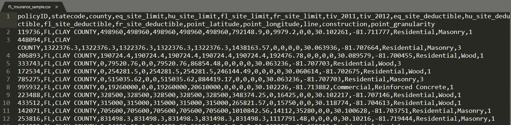

Trennung von einzelnen Daten durch `,` oder `;` (im deutschsprachigen Raum)

In R laden mit: `read.csv()` (Kommatrennung) oder `read.csv2()` (Semikolontrennung)

### read.csv(): Argumente

basiert auf `read.table()`, bei dem wir den Trenner händisch einstellen können.

`header`: TRUE oder FALSE, falls die erste Zeile die Spaltentitel enthält

`sep`: Der Trenner, hier per default ein Komma

`quote`: Die Zeichen, die dafür sorgen, dass Sätze mit Kommas nicht getrennt werden.

`dec`: Das Zeichen, das für Dezimaltrennung verwendet wird

`col.names`: eigene Titel für die Spalten als Vektor (`colClasses`fixiert die Klassen)

`nrows`: maximale Anzahl der Zeilen, die eingelesen werden sollen (im Gegensatz zu `skip`, das Zeilen auslässt)

`strip.white`: Löscht Leerzeichen vor und nach Texten

`stringsAsFactors`: Wenn FALSE werden Strings nicht automatisch zu Factors umgewandelt -> empfohlen!

`fileEnconding`: Setzt manuell das Encoding (oft UTF-8). Häufiges Problem beim Wechsel zwischen Win und Mac

### Nutzung von read.csv()

```
df <- read.csv("DATEIPFAD.csv", ARGUMENTE)
```

### Weitere read.table()-Abwandlungen

Für Text-Files

- `read.table()` flexible Überfunktion für Dateien mit festgelegtem Trenner
- `read.delim()` tab-separiert, mit . als Dezimalseparator
- `read.delim2()` tab-separiert, mit , als Dezimalseparator
- `read.csv()` komma-separiert, mit . als Dezimalseparator
- `read.csv2()` semikolon-separiert, mit , als Dezimalseparator
- `read.fwf()` festgelegte Zahl an Bytes pro Spalte

Bei schwierigeren Dateiformaten:

`readLines()`: hier lesen wir eine Datei Zeile für Zeile ein und können genau steuern, wie die Zeile vearbeitet wird

### Dateien schreiben

Zu jeder read-Funktion gibt es auch eine write-Funktion:

```
write.csv()
write.csv2()
write.fwf()
write.delim()
write.delim2()
```

### Alternative: readr-Package

Als Variante der Base R-Einlesefunktionen gibt es das Package `readr` von Hadley Wickham.

Es ist 10x schneller und funktioniert genauso, wie die Base-Funktionen. Bringen also was, wenn wir große oder viele Dateien einlesen wollen.

Beispiele:

```
read_csv()
read_csv2()
read_tsv()
```

Übrigens: Die read-Funktionen funktionieren auch mit Dateien aus dem Internet

```r
readr::read_tsv("http://www.sthda.com/upload/boxplot_format.txt")
```

```
# A tibble: 72 x 3
   Nom   variable Group
   <chr>    <int> <chr>
 1 IND1        10 A
 2 IND2         7 A
 3 IND3        20 A
 4 IND4        14 A
 5 IND5        14 A
 6 IND6        12 A
 7 IND7        10 A
 8 IND8        23 A
 9 IND9        17 A
10 IND10       20 A
# ... with 62 more rows
```

### Excel

Standardmässig kann R keine Exceldateien lesen.

Es gibt aber - wie so oft - ein drei Packages dafür: XLConnect, readxl und xlsx.

Wir sollten uns nur für eines entscheiden.

`install.package(xlsx)`

```
read.xlsx(DATEI, ARBEITSBLATT, header=TRUE, colClasses=NA)
read.xlsx2(DATEI, ARBEITSBLATT, header=TRUE, colClasses="character")
```

read.xlsx2 ist schneller bei großen Dateien, read.xlsx versucht die Klassen der Spalten zu erhalten

### Schreiben:

```
write.xlsx(x, DATEI, sheetName="ARBEITSBLATT", col.names=TRUE, row.names=TRUE, append=FALSE)

write.xlsx2(x, DATEI, sheetName="ARBEITSBLATT",col.names=TRUE, row.names=TRUE, append=FALSE)
```

### Verrücktere Formate

Eine kleine Zusammenstellung, welche Befehle und Packages bestimmte Dateiformate öffnen können

| Format | Befehl | Package |
| --- | --- | --- |
| JSON | fromJSON() | rjson oder jsonlite |
| XML | xmlTreeParse() | XML |
| HTML | readHTMLTable(url) | RCurl und XML, oder rvest |
| SPSS (SAV) | read.spss() | foreign |
| Stata (dta) | read.dta() | foreign |
| SAS | read.sas7bdat() | sas7bdat |
| RData | load() oder readRDS() | keines |

Was natürlich auch noch möglich ist: Verbindung zu Datenbanken oder Webscraping

Cheaterpackage `Data.table`: `fread()` rät alle Argumente von selbst und ist sehr schnell

### Daten konvertieren

- `as.numeric`
- `as.integer`
- `as.character`
- `as.logical`
- `as.factor`
- `as.ordered`
- `as.Date`
- `as.POSIXct`

**Trick:** Wir können auf einen Blick alle Klassen eines Dataframes mit `sapply(df, class)` bekommen

### Daten in Dataframe konvertieren: mtcars

> The data was extracted from the 1974 Motor Trend US magazine, and comprises fuel consumption and 10 aspects of automobile design and performance for 32 automobiles (1973–74 models).

```r
str(mtcars)
```

```
'data.frame':   32 obs. of  11 variables:
 $ mpg : num  21 21 22.8 21.4 18.7 18.1 14.3 24.4 22.8 19.2 ...
 $ cyl : num  6 6 4 6 8 6 8 4 4 6 ...
 $ disp: num  160 160 108 258 360 ...
 $ hp  : num  110 110 93 110 175 105 245 62 95 123 ...
 $ drat: num  3.9 3.9 3.85 3.08 3.15 2.76 3.21 3.69 3.92 3.92 ...
 $ wt  : num  2.62 2.88 2.32 3.21 3.44 ...
 $ qsec: num  16.5 17 18.6 19.4 17 ...
 $ vs  : num  0 0 1 1 0 1 0 1 1 1 ...
 $ am  : num  1 1 1 0 0 0 0 0 0 0 ...
 $ gear: num  4 4 4 3 3 3 3 4 4 4 ...
 $ carb: num  4 4 1 1 2 1 4 2 2 4 ...
```

### Factors bearbeiten: mtcars I

### Variable als Factor

```r
mtcars$gear <- as.ordered(mtcars$gear)

class(mtcars$gear)
```

```
[1] "ordered" "factor"
```

### Factor umcodieren

am: Transmission (0 = automatic, 1 = manual)

```r
recode <- c(automatic = 0, manual = 1)
factor(mtcars$am, levels = recode, labels = names(recode))
```

```
 [1] manual    manual    manual    automatic automatic automatic automatic
 [8] automatic automatic automatic automatic automatic automatic automatic
[15] automatic automatic automatic manual    manual    manual    automatic
[22] automatic automatic automatic automatic manual    manual    manual
[29] manual    manual    manual    manual
Levels: automatic manual
```

### Factors bearbeiten: mtcars II

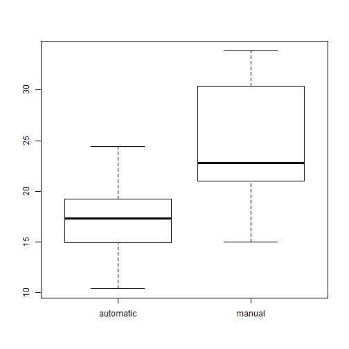

```r
mtcars$am <- factor(mtcars$am, levels = recode, labels = names(recode))
plot(mtcars$am, mtcars$mpg)
```

### POSIXct

- speichert Datum und Zeit
- berechnet ab dem 1. Januar 1970 00:00 Uhr

```r
aktuelle_zeit <- Sys.time()
class(aktuelle_zeit)
```

```
[1] "POSIXct" "POSIXt"
```

```r
aktuelle_zeit
```

```
[1] "2019-04-13 17:30:40 CEST"
```

Die Umwandlung von POSIXct ist kompliziert, denn man muss Zeitzonen und Formate im Blick behalten. Aber: as.POSIXct kann das alles handlen.

### POSIXct umwandeln

Ein Beispiel: Wir haben ein deutsches Datum und wollen das ins POSIXct-Format umwandeln

```r
de_datum <- "16.03.1991 02:10"
as.POSIXct(de_datum, format = "%d.%m.%Y %H:%M", tz = "MET")
```

```
[1] "1991-03-16 02:10:00 MET"
```

### Übung: Dateien öffnen

Auf dem Github-Repo liegen drei originale Datensätze in CSV und XLSX.

Öffnet sie, und versucht die Spaltennamen und Spaltenformate richtig anzugeben. Oder wandelt die Dateien nach dem einlesen so um, dass ihr damit weiterarbeiten könnt.

Die drei Dateien sind etwas unterschiedlich - vor allem unterschiedlich groß.

Empfohlene Reihenfolge nach aufsteigender Schwierigkeit:

Bierpreis, Fahrgastzählung, Wohnungen